# assignment 3

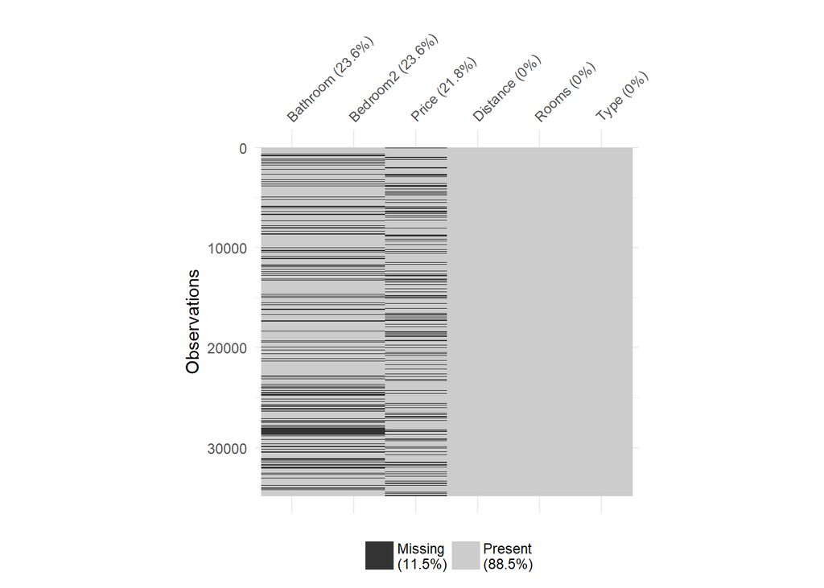

```r
library(tidyverse)
houses <- read_csv("Melbourne_housing_FULL.csv")
library(visdat)
melhousing <- houses %>%
select(Price, Rooms, Type, Distance, Bedroom2, Bathroom)
vis_miss(melhousing, sort_miss=TRUE) + theme(aspect.ratio=1)
```

As can be seen from the graph above, clearly, there is a large amount of missing values in variables such as Price, Bedroom2, and Bedroom.Then, we can do a missing values summary to have a better understanding of this dataset.

```r
library(naniar)
miss_summary(melhousing)
```

```
## # A tibble: 1 x 7
##   miss_df_prop miss_var_prop miss_case_prop miss_case_table miss_var_table
##          <dbl>         <dbl>          <dbl> <list>          <list>
## 1        0.115         0.667          0.403 <tibble [4 x 3~ <tibble [5 x ~
## # ... with 2 more variables: miss_var_summary <list>,
## #   miss_case_summary <list>
```

According to the summary, the proportion of missing variables and missing cases are relatively high. As Observations (rows) with many missings are better to be dropped, cases with missing reponse values can’t be used, we can just drop those observations who have missing value in the variables Price, Rooms, Type, Distance, Bedroom2, Bathroom.

```r
library(tidyverse)
library(labelled)
```

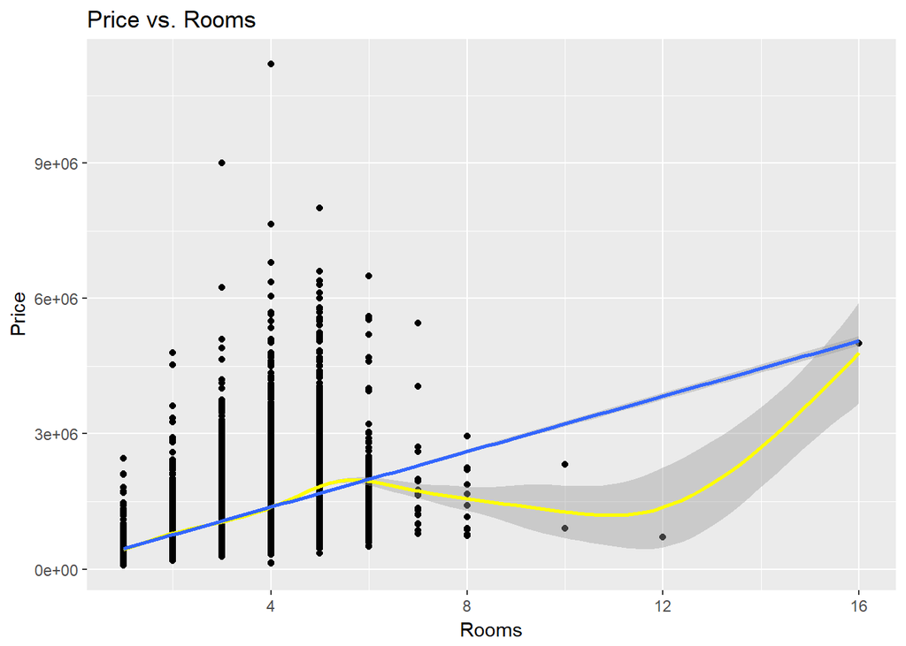

```r
melhousing2 <- houses %>%
filter(!is.na(Price)) %>%
filter(!is.na(Bedroom2)) %>%
filter(!is.na(Bathroom)) %>%
select(Price, Rooms, Type, Distance, Bedroom2, Bathroom)


#1
ggplot(data=melhousing2, aes(x=Rooms, y=Price)) + geom_point()+geom_smooth(color = "yellow")+geom_smooth(method="lm")+ggtitle("Price vs. Rooms")
```

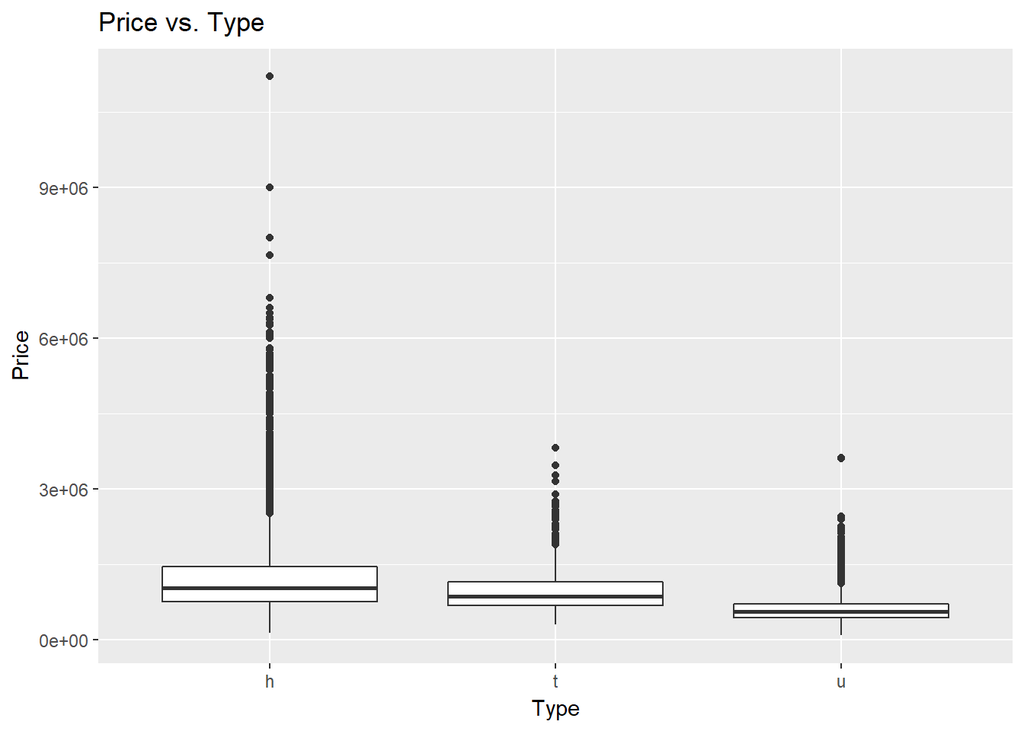

```r
#2
ggplot(data=melhousing2, aes(x=Type, y=Price)) + geom_boxplot()+ggtitle("Price vs. Type")
```

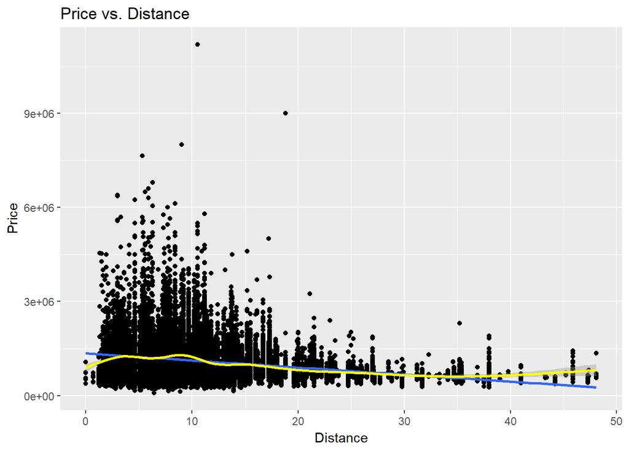

```r
#3
ggplot(data=melhousing2, aes(x=Distance, y=Price)) + geom_point()+geom_smooth(method="lm")+geom_smooth(color = "yellow")+ggtitle("Price vs. Distance")
```

Here we have three graphs

In the Price vs Rooms graph, we can see that its shape is most likely to be a positive skewed graph. The majority of the houses have rooms between 1 and 4, with less rooms from 5 to 8. The regression line has a positive gradient, indicating that as the number of rooms increase, so does its price, although there are some outliers in this dataset.

In the Price vs Type graph, we have three box plots being shown here. The first one, h, stands for standard houses. Here we can see that it has the largest span of price, followed by townhouse and units. The mean value for h is also the highest, followed by t and finally, u. After analysing the boxplots themselves, taking notice of their quartiles, mean and range, we can conclude that the price for standard houses are the most expensive, as its mean and range are both higher than the other two.

In the Price vs Distance graph, we can see a negative gradient in the regression line. This shows that the further the house is, the less expensive it will be. This is reflected in the graph as we see that most of the houses are ranged between 0 and 20, with some of the higher priced houses (inbetween 3 million to 9 million) inside this range.

```r
melhousing2 <- houses %>%
filter(!is.na(Price)) %>%
filter(!is.na(Bedroom2)) %>%
filter(!is.na(Bathroom)) %>%
select(Price, Rooms, Type, Distance, Bedroom2, Bathroom) %>%
mutate(log_Price = log10(Price))
library(tidyr)
library(broom)
#1
price_lm1 <- lm(Price ~ Rooms + Type + Distance+Bedroom2+Bathroom, data=melhousing2)
tidy(price_lm1)
```

```
##          term   estimate  std.error  statistic       p.value
## 1 (Intercept)  652067.34 15351.7547  42.475101  0.000000e+00
## 2       Rooms  168344.31 13127.5205  12.823771  1.674293e-37
## 3       Typet -304850.36 13552.1086 -22.494681 9.796801e-111
## 4       Typeu -407348.31 11106.4038 -36.676886 2.021893e-285
## 5    Distance  -38669.85   526.0495 -73.509910  0.000000e+00
## 6    Bedroom2   12819.71 12806.4020   1.001039  3.168197e-01
## 7    Bathroom  260776.19  6377.9053  40.887436  0.000000e+00
```

```r
glance(price_lm1)
```

```
##   r.squared adj.r.squared    sigma statistic p.value df    logLik      AIC
## 1 0.4184069     0.4182391 497769.5  2493.134       0  7 -302362.6 604741.2
##        BIC     deviance df.residual
## 1 604804.7 5.151974e+15       20793
```

```r
#2
price_lm2 <- lm(log10(Price) ~ Rooms + Type + Distance+Bedroom2+Bathroom, data=melhousing2)
tidy(price_lm2)
```

```
##          term     estimate    std.error   statistic       p.value
## 1 (Intercept)  5.855726487 0.0048184998 1215.259268  0.000000e+00
## 2       Rooms  0.062899682 0.0041203729   15.265531  2.494837e-52
## 3       Typet -0.095808027 0.0042536396  -22.523776 5.162700e-111
## 4       Typeu -0.214134242 0.0034859992  -61.426935  0.000000e+00
## 5    Distance -0.014513565 0.0001651127  -87.900970  0.000000e+00
## 6    Bedroom2  0.008614274 0.0040195825    2.143077  3.211851e-02
## 7    Bathroom  0.069452809 0.0020018516   34.694284 1.907677e-256
```

```r
glance(price_lm2)
```

```
##   r.squared adj.r.squared     sigma statistic p.value df   logLik
## 1 0.5150264     0.5148865 0.1562363   3680.25       0  7 9102.396
##         AIC       BIC deviance df.residual
## 1 -18188.79 -18125.25 507.5529       20793
```

```r
#3
price_lm3 <- lm(log10(Price) ~ Rooms + Type + Distance+Bedroom2+Bathroom+Type*Rooms, data=melhousing2)
tidy(price_lm3)
```

```
##          term     estimate    std.error   statistic       p.value
## 1 (Intercept)  5.901435211 0.0051234041 1151.858232  0.000000e+00
## 2       Rooms  0.046779406 0.0041103455   11.380894  6.384459e-30
## 3       Typet -0.217164488 0.0176789511  -12.283788  1.458835e-34
## 4       Typeu -0.452444332 0.0100196359  -45.155766  0.000000e+00
## 5    Distance -0.014576470 0.0001626124  -89.639373  0.000000e+00
## 6    Bedroom2  0.008654838 0.0039580657    2.186633  2.878041e-02
## 7    Bathroom  0.074560169 0.0019825194   37.608797 1.582503e-299
## 8 Rooms:Typet  0.039353392 0.0059226631    6.644543  3.116886e-11
## 9 Rooms:Typeu  0.110651845 0.0044023634   25.134646 2.330983e-137
```

```r
glance(price_lm3)
```

```
##   r.squared adj.r.squared     sigma statistic p.value df logLik      AIC
## 1  0.529803     0.5296221 0.1538452   2928.33       0  9 9424.2 -18828.4
##         BIC deviance df.residual
## 1 -18748.97 492.0883       20791
```

Here are the three regressions we figured out. In the first regression, the intercept is shown to be at 652067.34. This indicates that with no other factors involved, the average house price in Melbourne is 652067.34 AUD. Of course, when we add othe variables to this, the price will certainly change. For example, each room brings up the price by an average of 168344.31 AUD. If the house is a townhouse or a unit, its price will decrease by 304850.36 AUD and 407348.31 AUD respectively. For each unit increase in distance, its price will drop on average by 38669.85 AUD. While looking at this regression, the standard error is relatively high. This means taht our mean is far from the true mean of our population. Realising this data is positively skewed, we used a log transformation.

It is also necessary to notice that the coefficient ‘typet’ and ‘typeu’ are both compared to a dummy variable, ‘typeh’.

In the third regression, we’ve added two more coefficients, Rooms:Typet and Rooms:Typeu. By adding these coefficients, R squared and adjusted R squared both became larger than before, while it is still a log-level model.